# Cop1 case study

Nastassia Gobet

2021-07-09

# Goal

Explore a gene expression and gene counts for a gene which differ for GRCm38 and BXD-specific references.

# Information

Doing this in default STAR setting (genotypesandimputed_withannotation_Local_0_10) because also available with B6 mm10 reference (abbreviated B6)

FastQTL output (http://fastqtl.sourceforge.net/):

- rowname = ID molecular phenotype (gene)
- V2 = number of variant tested
- V3 = MLE of shape 1 parameter of beta distribution
- V4 = MLE of shape 2 parameters of beta distribution
- V5 = to be described (not explained on FastQTL website)
- V6 = ID of best variant
- V7 = distance between variant and molecular phenotype
- V8 = p-value of association between variant and molecular phenotype
- V9 = slope of regression
- V10 = first permutation p-value accounting for multiple variants tested by molecular phenotype
- V11 = second permutation p-value obtained with beta approximation (recommended to use this one)

# Preparation

## Functions definitions

```r
prepareRawCounts <- function(counts, ref){

  # convert gene ids to gene names
  idx_uniq <- which(!duplicated(GeneConvert$V2[match(rownames(counts), GeneConvert$V1)]))
  counts <- counts[idx_uniq,]
  rownames(counts) <- GeneConvert$V2[match(rownames(counts), GeneConvert$V1)]

  # change X into C for cortex
  colnames(counts) <- gsub("X", "C", colnames(counts))
  # split by tissue and condition
  CortexNSD <- subset(counts, select=grep("^C[0-9]*nsd$", colnames(counts), value=TRUE))
  CortexSD <- subset(counts, select=grep("^C[0-9]*sd$", colnames(counts), value=TRUE))
  LiverNSD <- subset(counts, select=grep("^L[0-9]*nsd$", colnames(counts), value=TRUE))
  LiverSD <- subset(counts, select=grep("^L[0-9]*sd$", colnames(counts), value=TRUE))
  # clean and formate names of mouse lines
  colnames(CortexNSD) <- LinesNames$V5[match(gsub("[LCnsd]", "", colnames(CortexNSD)), LinesNames$V10)]
  colnames(CortexSD) <- LinesNames$V5[match(gsub("[LCnsd]", "", colnames(CortexSD)), LinesNames$V10)]
  colnames(LiverNSD) <- LinesNames$V5[match(gsub("[LCnsd]", "", colnames(LiverNSD)), LinesNames$V10)]
  colnames(LiverSD) <- LinesNames$V5[match(gsub("[LCnsd]", "", colnames(LiverSD)), LinesNames$V10)]

  # output 4 datasets
  assign(paste0("counts", ref, "ref_CortexNSD"), CortexNSD, envir=parent.frame())
  assign(paste0("counts", ref, "ref_CortexSD"), CortexSD, envir=parent.frame())
  assign(paste0("counts", ref, "ref_LiverNSD"), LiverNSD, envir=parent.frame())
  assign(paste0("counts", ref, "ref_LiverSD"), LiverSD, envir=parent.frame())
}

# plot gene expression for a pair gene-variant
plotGeneExpressionVariant <- function(ref, gene, variant, tissue, condition){
  # get first letter of tissue
   t <- unlist(strsplit(tissue, split=""))[1]
  # get gene expression dataset
  expr <- eval(parse(text=paste0("expr", ref, "ref", t, condition)))
  # plot
  plot(as.numeric(expr[gene, sort(names(expr))]), pch=19, col=as.factor(genotypesGN[genotypesGN$Locus==variant, sort(names(expr))]), main=paste0("Gene: ", gene,", ref: ", ref, ", variant: ", variant, ", tissue: ", tissue, ", condition: ", condition), xaxt="n", xlab="", ylab="gene expression", las=1)
  axis(1, 1:length(names(expr)), sort(names(expr)), las=2)
}
# vectorize function
plotGeneExpressionVariant <- Vectorize(plotGeneExpressionVariant, SIMPLIFY=FALSE)

# plot raw gene counts for a pair gene-variant
plotGeneCountsVariant <- function(ref, gene, variant, tissue, condition){
  # get gene expression dataset
  counts <- eval(parse(text=paste0("counts", ref, "ref_", tissue, condition)))
  # plot
  plot(as.numeric(counts[gene, sort(names(counts))]), pch=19, col=as.factor(genotypesGN[genotypesGN$Locus==variant, sort(names(counts))]), main=paste0("Gene: ", gene,", ref: ", ref, ", variant: ", variant, ", tissue: ", tissue, ", condition: ", condition), xaxt="n", xlab="", ylab="raw gene counts", las=1)
  axis(1, 1:length(names(counts)), sort(names(counts)), las=2)
}
# vectorize function
plotGeneCountsVariant <- Vectorize(plotGeneCountsVariant, SIMPLIFY=FALSE)
```

## Data preparation

```r
# load table to convert mouse line names
LinesNames <- read.table("F:/BXD/data/ConvertLineNames.tsv", header=FALSE, stringsAsFactors=FALSE, sep="\t")

# load table to convert between gene id and gene name
GeneConvert <- read.table("F:/BXD/references/gene_names_B6mm10.tab", header=FALSE, stringsAsFactors=FALSE, sep="\t")

# retrieve GeneNetwork (GN) genotypes
genotypesGN <- read.table("F:/BXD/data/genome/BXDGenotypes.geno", header=TRUE)

# retrieve raw gene counts, formate and subset
countsB6ref <- read.table("F:/BXD/data/transcriptome/2_mapping_STAR/OnGenomeAndAnnotation/B6mm10primaryassembly_withannotation/Summary_ReadsPerGene.out.tab", header=TRUE, row.names=1)
prepareRawCounts(countsB6ref, "B6")
countsBXDref <- read.table("F:/BXD/data/transcriptome/2_mapping_STAR/OnGenomeAndAnnotation/BXDfromGNandimputedD2blocks_withannotation/Summary_ReadsPerGene.out.tab", header=TRUE, row.names=1)
prepareRawCounts(countsBXDref, "BXD")

# retrieve gene expression
exprB6refCNSD <- read.table("F:/BXD/data/transcriptome/2_mapping_STAR/OnGenomeAndAnnotation/B6mm10primaryassembly_withannotation/TMMnormalized_log2CPM_Cortex_NSD.tab")
exprBXDrefCNSD <- read.table("F:/BXD/data/transcriptome/2_mapping_STAR/OnGenomeAndAnnotation/BXDfromGNandimputedD2blocks_withannotation/TMMnormalized_log2CPM_Cortex_NSD.tab")
exprB6refCSD <- read.table("F:/BXD/data/transcriptome/2_mapping_STAR/OnGenomeAndAnnotation/B6mm10primaryassembly_withannotation/TMMnormalized_log2CPM_Cortex_SD.tab")
exprBXDrefCSD <- read.table("F:/BXD/data/transcriptome/2_mapping_STAR/OnGenomeAndAnnotation/BXDfromGNandimputedD2blocks_withannotation/TMMnormalized_log2CPM_Cortex_SD.tab")
exprB6refLNSD <- read.table("F:/BXD/data/transcriptome/2_mapping_STAR/OnGenomeAndAnnotation/B6mm10primaryassembly_withannotation/TMMnormalized_log2CPM_Liver_NSD.tab")
exprBXDrefLNSD <- read.table("F:/BXD/data/transcriptome/2_mapping_STAR/OnGenomeAndAnnotation/BXDfromGNandimputedD2blocks_withannotation/TMMnormalized_log2CPM_Liver_NSD.tab")
exprB6refLSD <- read.table("F:/BXD/data/transcriptome/2_mapping_STAR/OnGenomeAndAnnotation/B6mm10primaryassembly_withannotation/TMMnormalized_log2CPM_Liver_SD.tab")
exprBXDrefLSD <- read.table("F:/BXD/data/transcriptome/2_mapping_STAR/OnGenomeAndAnnotation/BXDfromGNandimputedD2blocks_withannotation/TMMnormalized_log2CPM_Liver_SD.tab")

# eQTLs mapped on GRCm38
eQTLB6refCNSD <- read.table("F:/BXD/data/transcriptome/eQTL_B6mm10primaryassembly_withannotation/TMMnormalized_log2CPM_Cortex_NSD_grouped.tab", stringsAsFactors=FALSE)
eQTLB6refCSD <- read.table("F:/BXD/data/transcriptome/eQTL_B6mm10primaryassembly_withannotation/TMMnormalized_log2CPM_Cortex_SD_grouped.tab", stringsAsFactors=FALSE)
eQTLB6refLNSD <- read.table("F:/BXD/data/transcriptome/eQTL_B6mm10primaryassembly_withannotation/TMMnormalized_log2CPM_Liver_NSD_grouped.tab", stringsAsFactors=FALSE)
eQTLB6refLSD <- read.table("F:/BXD/data/transcriptome/eQTL_B6mm10primaryassembly_withannotation/TMMnormalized_log2CPM_Liver_SD_grouped.tab", stringsAsFactors=FALSE)
# eQTLs mapped on BXD-specific references
eQTLBXDrefCNSD <- read.table("F:/BXD/data/transcriptome/eQTL_BXDfromGNandimputedD2blocks_withannotation/TMMnormalized_log2CPM_Cortex_NSD_grouped.tab", stringsAsFactors=FALSE)
eQTLBXDrefCSD <- read.table("F:/BXD/data/transcriptome/eQTL_BXDfromGNandimputedD2blocks_withannotation/TMMnormalized_log2CPM_Cortex_SD_grouped.tab", stringsAsFactors=FALSE)
eQTLBXDrefLNSD <- read.table("F:/BXD/data/transcriptome/eQTL_BXDfromGNandimputedD2blocks_withannotation/TMMnormalized_log2CPM_Liver_NSD_grouped.tab", stringsAsFactors=FALSE)
eQTLBXDrefLSD <- read.table("F:/BXD/data/transcriptome/eQTL_BXDfromGNandimputedD2blocks_withannotation/TMMnormalized_log2CPM_Liver_SD_grouped.tab", stringsAsFactors=FALSE)
```

# Gene selection

```r
# get common genes between eQTL list GRCm38 reference and BXD-specific references
commongenes <- intersect(rownames(eQTLB6refCNSD)[!is.na(eQTLB6refCNSD[, "slope"])], rownames(eQTLBXDrefCNSD)[!is.na(eQTLBXDrefCNSD[, "slope"])])

# eQTLs with different sign of slope
changeofsign <- commongenes[sign(eQTLB6refCNSD[commongenes, "slope"])!=sign(eQTLBXDrefCNSD[commongenes, "slope"])]
# eQTLs with different genetic marker
changeofmarker <- commongenes[eQTLB6refCNSD[commongenes, "marker"]!=eQTLBXDrefCNSD[commongenes, "marker"]]

# eQTLs significant with GRCm38 reference
sig_eQTLB6 <- commongenes[which(eQTLB6refCNSD[commongenes, "adjustedpvalue"]<0.05)]
# eQTLs significant with BXD-specific references
sig_eQTLBXD <- commongenes[which(eQTLBXDrefCNSD[commongenes, "adjustedpvalue"]<0.05)]


# select interesting genes (change of marker AND change of sign AND is significant with both GRCm38 and BXD-specific references)
genes <- intersect(intersect(intersect(changeofmarker, changeofsign), sig_eQTLBXD), sig_eQTLB6)

# take only the first one
gene <- genes[1]

# select markers id
B6marker <- eQTLB6refCNSD[gene, "marker"]
BXDmarker <- eQTLBXDrefCNSD[gene, "marker"]
```

The gene selected is *Cop1*. The eQTL change of marker and sign of slope between GRCm38 and BXD-specific references, and it is significant (q-value < 0.05) for both. It is the first one of a list of 9 genes.

- The marker for eQTL with B6 reference is rs33739489.
- The marker for eQTL with BXD-sepcific references is rs33740307.

This analysis was done in the Cortex NSD.

# Cop1 eQTL details other tissue and condition

```r
eQTLB6refCNSD[gene, ]
```

|  | nb_variants_tested | MLE1_beta | MLE2_beta | TBD | distance | pvalue | slope | pvalue_firstpermutation | pvalue_secondpermutation | adjustedpvalue | marker |
| --- | --- | --- | --- | --- | --- | --- | --- | --- | --- | --- | --- |
| Cop1 | 12 | 0.880763 | 2.1767 | 35.7348 | -850850 | 1.43567e-10 | -0.138573 | 0.000999001 | 2.47518e-10 | 2.888395e-09 | rs33739489 |

```r
eQTLBXDrefCNSD[gene, ]
```

|  | nb_variants_tested | MLE1_beta | MLE2_beta | TBD | distance | pvalue | slope | pvalue_firstpermutation | pvalue_secondpermutation | adjustedpvalue | marker |
| --- | --- | --- | --- | --- | --- | --- | --- | --- | --- | --- | --- |
| Cop1 | 12 | 0.881471 | 2.25219 | 35.6379 | -851647 | 0.00023717 | 0.0636791 | 0.001998 | 0.000511256 | 0.001704089 | rs33740307 |

```r
eQTLB6refCSD[gene, ]
```

|  | nb_variants_tested | MLE1_beta | MLE2_beta | TBD | distance | pvalue | slope | pvalue_firstpermutation | pvalue_secondpermutation | adjustedpvalue | marker |
| --- | --- | --- | --- | --- | --- | --- | --- | --- | --- | --- | --- |
| Cop1 | 12 | 0.860368 | 2.26863 | 37.7691 | -850850 | 1.13322e-08 | -0.123836 | 0.000999001 | 1.24998e-08 | 8.723768e-08 | rs33739489 |

```r
eQTLBXDrefCSD[gene, ]
```

|  | nb_variants_tested | MLE1_beta | MLE2_beta | TBD | distance | pvalue | slope | pvalue_firstpermutation | pvalue_secondpermutation | adjustedpvalue | marker |
| --- | --- | --- | --- | --- | --- | --- | --- | --- | --- | --- | --- |
| Cop1 | 12 | 0.927397 | 2.34067 | 37.091 | -850850 | 2.88849e-07 | 0.0962624 | 0.000999001 | 1.56001e-07 | 9.021381e-07 | rs33739489 |

```r
eQTLB6refLNSD[gene, ]
```

|  | nb_variants_tested | MLE1_beta | MLE2_beta | TBD | distance | pvalue | slope | pvalue_firstpermutation | pvalue_secondpermutation | adjustedpvalue | marker |
| --- | --- | --- | --- | --- | --- | --- | --- | --- | --- | --- | --- |
| Cop1 | 12 | 0.881512 | 2.32736 | 37.7691 | -850850 | 0.00212873 | -0.0721332 | 0.010989 | 0.0035055 | 0.01062967 | rs33739489 |

```r
eQTLBXDrefLNSD[gene, ]
```

|  | nb_variants_tested | MLE1_beta | MLE2_beta | TBD | distance | pvalue | slope | pvalue_firstpermutation | pvalue_secondpermutation | adjustedpvalue | marker |
| --- | --- | --- | --- | --- | --- | --- | --- | --- | --- | --- | --- |
| Cop1 | 12 | 0.887947 | 2.25539 | 36.5703 | -850850 | 8.85023e-10 | 0.192682 | 0.000999001 | 8.58324e-10 | 1.067116e-08 | rs33739489 |

```r
eQTLB6refLSD[gene, ]
```

|  | nb_variants_tested | MLE1_beta | MLE2_beta | TBD | distance | pvalue | slope | pvalue_firstpermutation | pvalue_secondpermutation | adjustedpvalue | marker |
| --- | --- | --- | --- | --- | --- | --- | --- | --- | --- | --- | --- |
| Cop1 | 12 | 0.904562 | 2.31656 | 38.4957 | -851647 | 0.00119636 | -0.0682351 | 0.001998 | 0.0014165 | 0.006201796 | rs33740307 |

```r
eQTLBXDrefLSD[gene, ]
```

|  | nb_variants_tested | MLE1_beta | MLE2_beta | TBD | distance | pvalue | slope | pvalue_firstpermutation | pvalue_secondpermutation | adjustedpvalue | marker |
| --- | --- | --- | --- | --- | --- | --- | --- | --- | --- | --- | --- |
| Cop1 | 12 | 0.87491 | 2.22673 | 36.4492 | -850850 | 8.93757e-11 | 0.220057 | 0.000999001 | 1.17245e-10 | 2.315443e-09 | rs33739489 |

# Plotting

Legend:

- black = B6 allele
- tan = D2 allele
- red = heterozygous

```r
# define color palette
palette(c("black", "tan", "red"))
```

## Cop1 gene expression Cortex NSD

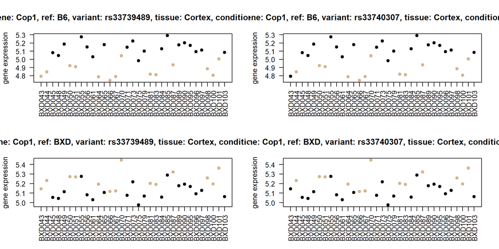

```r
par(mfrow=c(2,2))

# plot variant-gene expression pair
invisible(plotGeneExpressionVariant(ref=c("B6", "B6", "BXD", "BXD"), gene=gene, variant=c(B6marker, BXDmarker), tissue="Cortex", condition="NSD"))
```

## Cop1 gene counts Cortex NSD

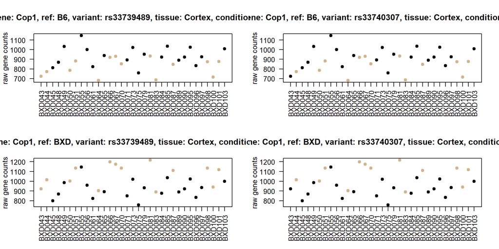

```r
par(mfrow=c(2,2))

# plot variant-gene count pair
invisible(plotGeneCountsVariant(ref=c("B6", "B6", "BXD", "BXD"), gene=gene, variant=c(B6marker, BXDmarker), tissue="Cortex", condition="NSD"))
```